# gapminder_exploration

## Bring the rectangular data in

```r
library(gapminder)
library(tidyverse)
```

## Small test the data

1. Is it a data.frame, a matrix,a vector, a list? Answer: This is a list.

```r
typeof(gapminder)
```

```
## [1] "list"
```

2. What is its class?

```r
class(gapminder) ##class
```

```
## [1] "tbl_df"     "tbl"        "data.frame"
```

3. How many varables/column?

```r
ncol(gapminder) ## number of column
```

```
## [1] 6
```

4. How mant rows/observation?

```r
nrow(gapminder)
```

```
## [1] 1704
```

5. Get these facts about extent or size in more than one way?

```r
length(gapminder) ## return the length of the vectors therefore the number of column
```

```
## [1] 6
```

```r
dim(gapminder)  ## return the dimension of the vector in the format of row by column, therefore, 1704 rows and 6 column for this database
```

```
## [1] 1704    6
```

```r
nrow <- dim(gapminder)[1] ## return number of rows
ncol <- dim(gapminder)[2] ## return number of columns
```

6.What data type is each variable?

```r
typeof(gapminder$country)
```

```
## [1] "integer"
```

```r
typeof(gapminder$gdpPercap)
```

```
## [1] "double"
```

```r
typeof(gapminder$continent)
```

```
## [1] "integer"
```

```r
typeof(gapminder$year)
```

```
## [1] "integer"
```

```r
typeof(gapminder$pop)
```

```
## [1] "integer"
```

```r
typeof(gapminder$lifeExp)
```

```
## [1] "double"
```

## Exploring individual varaibles

Categorical variable:continent Quantitative variable:year

```r
summary(gapminder)
```

```
##         country        continent        year         lifeExp
##  Afghanistan:  12   Africa  :624   Min.   :1952   Min.   :23.60
##  Albania    :  12   Americas:300   1st Qu.:1966   1st Qu.:48.20
##  Algeria    :  12   Asia    :396   Median :1980   Median :60.71
##  Angola     :  12   Europe  :360   Mean   :1980   Mean   :59.47
##  Argentina  :  12   Oceania : 24   3rd Qu.:1993   3rd Qu.:70.85
##  Australia  :  12                  Max.   :2007   Max.   :82.60
##  (Other)    :1632
##       pop              gdpPercap
##  Min.   :6.001e+04   Min.   :   241.2
##  1st Qu.:2.794e+06   1st Qu.:  1202.1
##  Median :7.024e+06   Median :  3531.8
##  Mean   :2.960e+07   Mean   :  7215.3
##  3rd Qu.:1.959e+07   3rd Qu.:  9325.5
##  Max.   :1.319e+09   Max.   :113523.1
##
```

```r
summary(gapminder$continent) ##sorting the possible continent and also the number of country each continent contains
```

```
##   Africa Americas     Asia   Europe  Oceania
##      624      300      396      360       24
```

```r
max(gapminder$year)
```

```
## [1] 2007
```

```r
min(gapminder$year)
```

```
## [1] 1952
```

```r
var(gapminder$year)
```

```
## [1] 298.0916
```

As we can explore from the summary, for variable Continent, the possible values are Africa, Americas, Asia, Europe and Oceania. As for the quantitative variable year, the range of variable is from 1952 to 2007.

```r
summary(gapminder$year)
```

```
##    Min. 1st Qu.  Median    Mean 3rd Qu.    Max.
##    1952    1966    1980    1980    1993    2007
```

As shown from the above data, although year is ranging from 1952-2007, the most typical values are ranging from 1966 to 1993 with a median and mean of 1980.t The variance of this variable is 298.0916.

For the variable continent, the most typical value is Africa and the continent Oceania has less entries.

## Explore various plot types

This is the scatterplot of pop vs gdpPercap

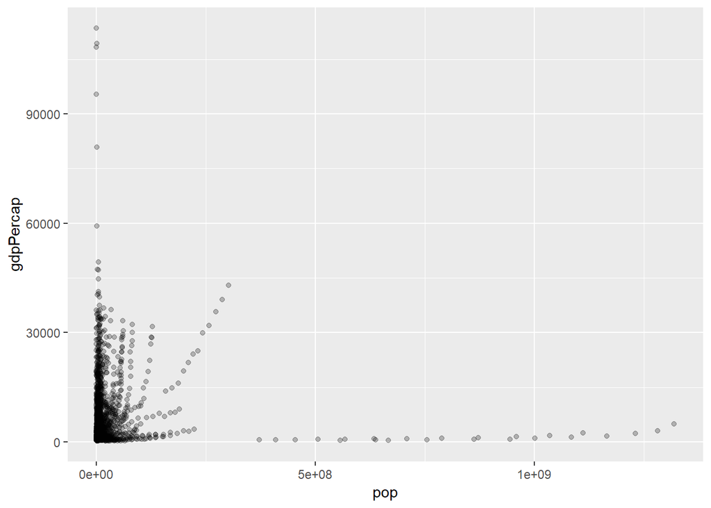

```r
ggplot(gapminder,aes(pop,gdpPercap))+
  geom_point(alpha=0.25)
```

This is a histogram of pop and the bin is set to be 50.

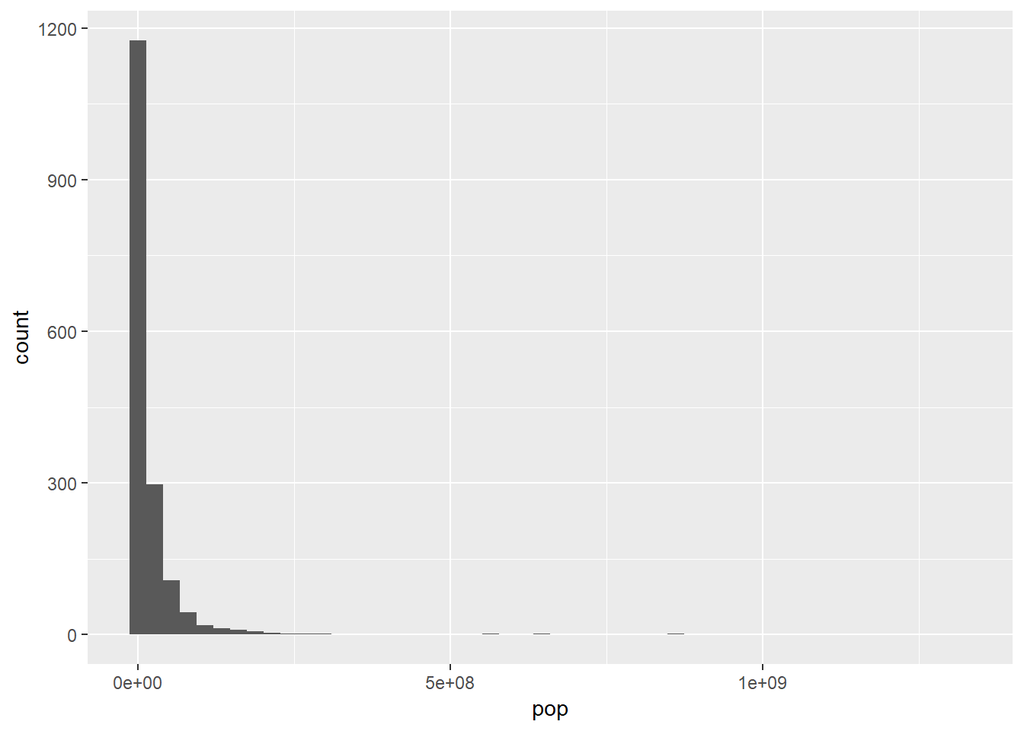

```r
ggplot(gapminder,aes(pop))+
  geom_histogram(bins=50)
```

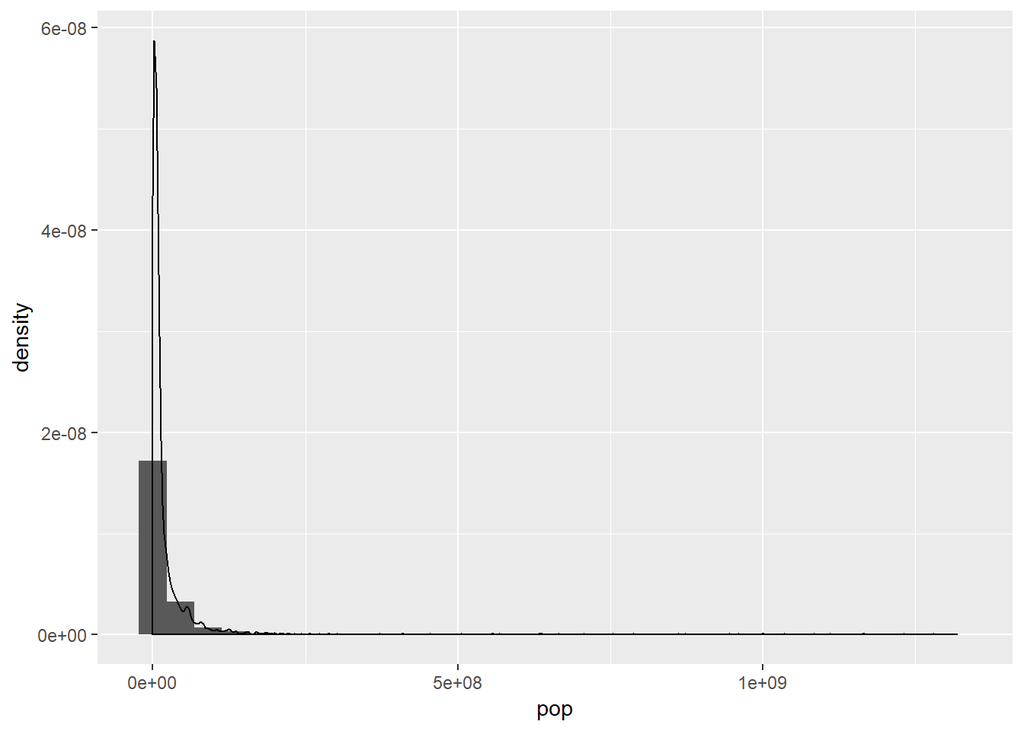

```r
ggplot(gapminder,aes(pop))+
  geom_histogram(aes(y=..density..))+
  geom_density()
```

This is a boxplot of lifeExp for each continent.

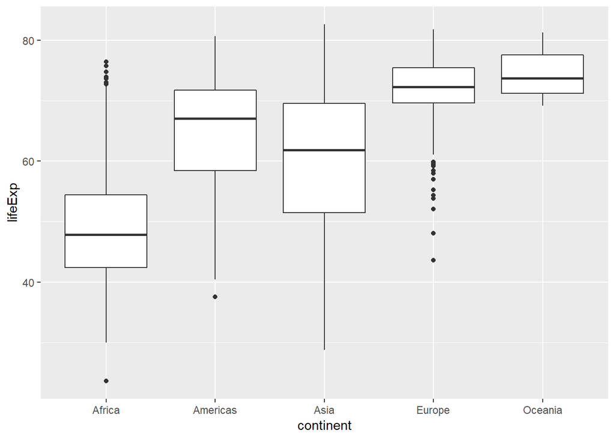

```r
ggplot(gapminder,aes(continent,lifeExp))+
  geom_boxplot()
```

This is the violin plot of lifeExp for each continent

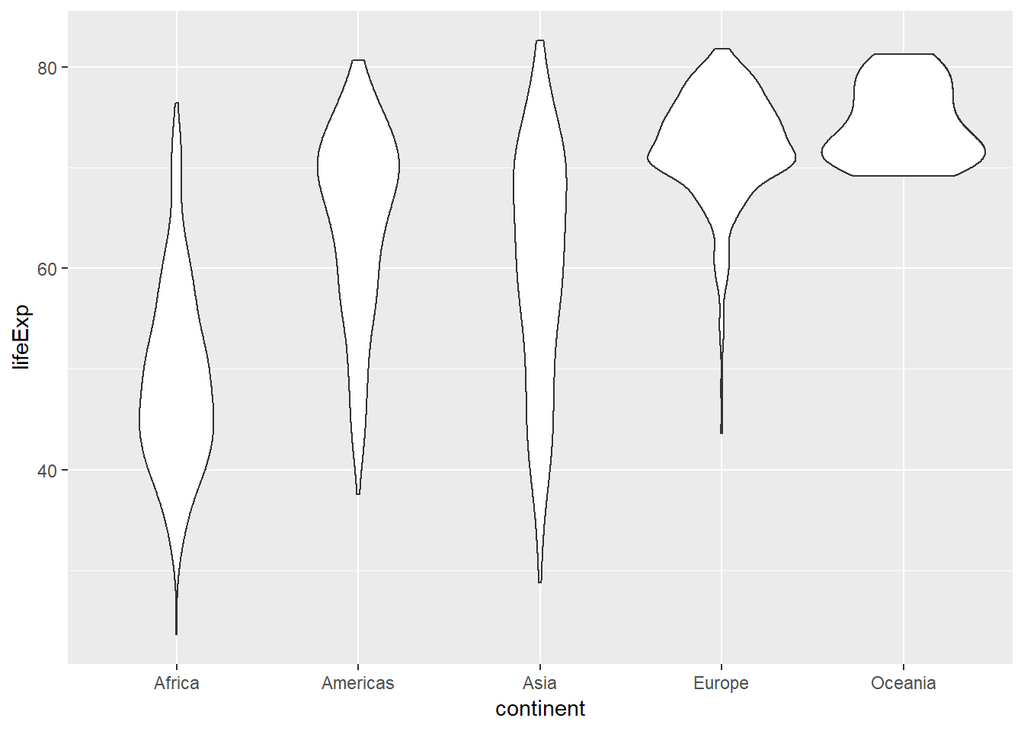

```r
ggplot(gapminder,aes(continent,lifeExp))+
  geom_violin()
```

## Using filter(), select() and %>%

filter the data to continent Oceania only and the various plots are shown below:

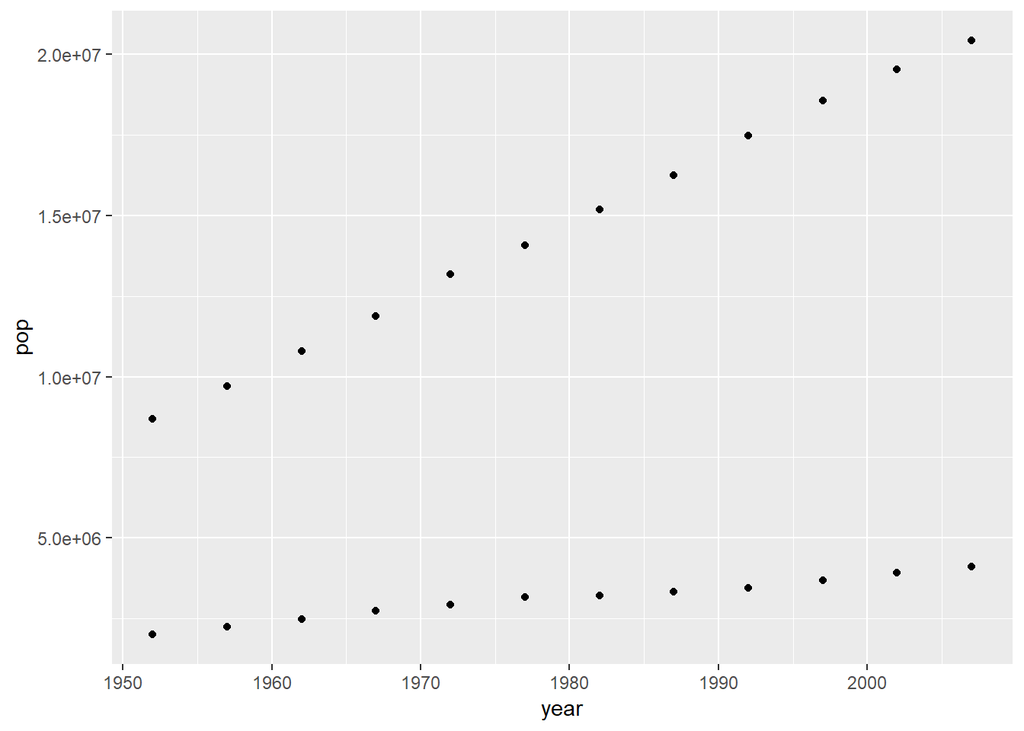

```r
gapminder %>%
  filter(continent=="Oceania") %>%
  ggplot(aes(year, pop))+
 geom_point()
```

select only variables lifeExp and continent and plot the boxplot and jitter plot of lifeExp for each continent.

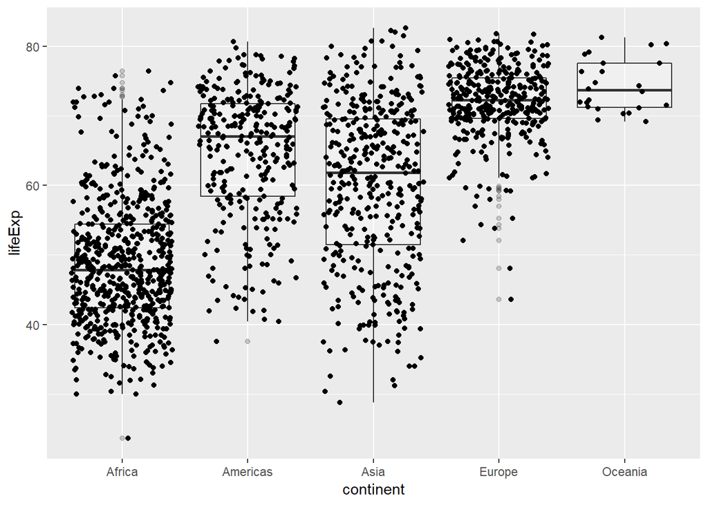

```r
gapminder %>%
 select(lifeExp,continent) %>%
  ggplot(aes(continent,lifeExp))+
  geom_boxplot(alpha=0.25)+
  geom_jitter()
```

## Extra Work

```r
filter(gapminder, country == c("Rwanda", "Afghanistan"))
```

```
## # A tibble: 12 x 6
##    country     continent  year lifeExp      pop gdpPercap
##    <fct>       <fct>     <int>   <dbl>    <int>     <dbl>
##  1 Afghanistan Asia       1957    30.3  9240934      821.
##  2 Afghanistan Asia       1967    34.0 11537966      836.
##  3 Afghanistan Asia       1977    38.4 14880372      786.
##  4 Afghanistan Asia       1987    40.8 13867957      852.
##  5 Afghanistan Asia       1997    41.8 22227415      635.
##  6 Afghanistan Asia       2007    43.8 31889923      975.
##  7 Rwanda      Africa     1952    40    2534927      493.
##  8 Rwanda      Africa     1962    43    3051242      597.
##  9 Rwanda      Africa     1972    44.6  3992121      591.
## 10 Rwanda      Africa     1982    46.2  5507565      882.
## 11 Rwanda      Africa     1992    23.6  7290203      737.
## 12 Rwanda      Africa     2002    43.4  7852401      786.
```